# Introduction to Statistical Analysis

Dr. Anil Chaturvedi

```r
# Let us generate a random Normal population of 100,000 with Mean 100 and standard deviation 10.
require(lattice)
```

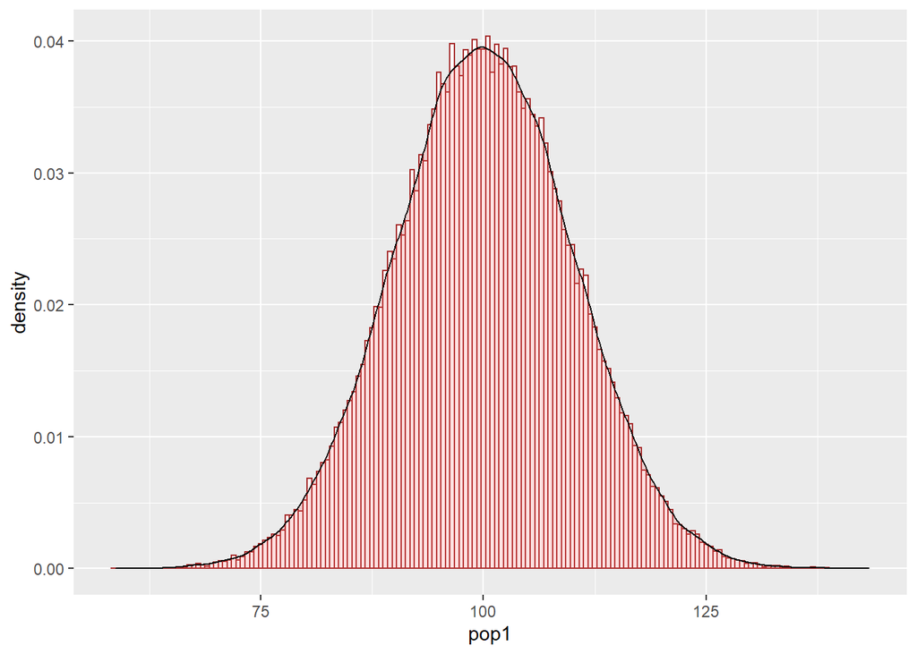

```r
require(ggplot2)
set.seed(123)
dat = data.frame(pop1 = rnorm(100000, 100,10),
                 pop2 = runif(100000, 0,100))

#lattice::histogram(pop)

ggplot(dat, aes(x=pop1)) +
    geom_histogram(aes(y=..density..),
                   binwidth=.5,
                   colour="Brown", fill="White") +
    geom_density(alpha=.2, fill="#FF6666")
```

```r
#    geom_density()
#
```

# What is the probability of getting a number between -19.6 and +19.6 from this population N(100,10)?

```r
pnorm(100+19.6,100,10) - pnorm (100-19.6,100,10)
```

```
## [1] 0.9500042
```

```r
length(dat$pop1[dat$pop1 <= 119.6 & dat$pop1 > 80.4])/100000
```

```
## [1] 0.95007
```

# 95% of data will lie Within 1.96 standard deviations away from mean. This 95% number can be stated as the following: that you are 95% sure or 95% confident that a random draw from a population with a mean of 100 and a standard deviation of 10 will lie in the interval [80.4, 119.6]. This can be interpreted as your “Confidence” of getting a value in that interval from a single random draw. This is called the Confidence Interval.

# In statistics, the word Confidence Interval is associated when one makes such statements using data from a sample, not a population.